# Topic: Classification using Decision Trees

MSDA - MSDA7003 Machine Learning

KT Wong

Faculty of Social Sciences, HKU

2024-10-31

The materials in this topic are drawn from Lantz (2023) and James et al. (2023)

$\newcommand{\E}{\mathbb{E}} \newcommand{\E}{\mathbb{E}} \newcommand{\var}{\mathrm{var}} \newcommand{\cov}{\mathrm{cov}} \newcommand{\Var}{\mathrm{var}} \newcommand{\Cov}{\mathrm{cov}} \newcommand{\Corr}{\mathrm{corr}} \newcommand{\corr}{\mathrm{corr}} \newcommand{\L}{\mathrm{L}} \renewcommand{\P}{\mathrm{P}} \newcommand{\independent}{{\perp\!\!\!\perp}} \newcommand{\indicator}[1]{ \mathbf{1}\{#1\} }$

## Things to discuss

1. Assignments
   - release of graded assignments
   - relevance of the assignments to the course materials
2. Cut topics
   - focus on decision trees and its extensions
   - model evaluation and selection, including regularization and cross-validation
   - ensemble methods
3. less mathematical details
   - more on the implementation of the models
4. Test
   - allow to bring a A4-size cheat sheet
   - to a pass (in fact, I mean B range): focus on the concepts, models, and its implementation
   - to get A range: deep understanding of the concepts and models (normally means using rigorous arguments)
5. Class arrangement
   - end the course on time
   - allow more time for you to digest the materials

## Motivation

- When deciding between job offers, many people begin by making lists of pros and cons, then eliminate options using simple rules
  - commute time for more than an hour
  - salary
  - medical benefit
- decompose complex decision of predicting one’s future career choice into a series of simple decisions
- utilize a **tree structure** to model the relationships among the features and the possible outcomes

## Motivation

- Job Offers Example

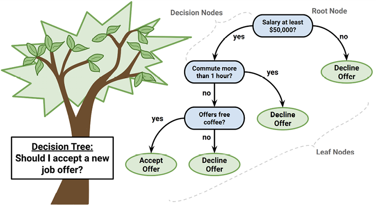

## Some terminologies in trees-based models

- Decision Trees
  - a flowchart-like structure in which each `internal node` represents a test on an attribute
  - each branch represents the outcome of the test
  - each `leaf (terminal) node` represents a class label
  - `Root Node` - starting point of the tree
- Classification Trees
  - used when the target variable is categorical
  - i.e. the outcome is a class label
- Regression Trees
  - used when the target variable is continuous
  - i.e. the outcome is a continuous value
- Data Scientists often use the term `tree-based models` to refer to both classification and regression trees
  - so-called **Classification And Regression Trees** (CART)

## Road Map

- Brief mention of benefits from using Trees
- when should and should not use it
- Divide and Conquer approach
- Potential Movie Proposal Example as illustration of classification trees
- Some details of the implementation of classification trees
- Regression trees
- Tree vs Linear Models

## Benefits from using trees-based model

- the flowchart-like tree structure is in a human-readable format
- This provides insight into how and why the model works or doesn’t work well for a particular task
- This also makes decision trees particularly appropriate for applications where
  - classification mechanism needs to be transparent for legal reasons
  - the results need to be shared with others to inform future business/research practice

## Some examples of its potential uses

- Credit scoring models
  - the criteria that cause an applicant to be rejected need to be clearly documented and free from bias
- Marketing studies of customer behavior
  - satisfaction or churn
  - for product improvement or advertising agencies
- Diagnosis of medical conditions
  - laboratory measurements
  - symptoms
  - rates of disease progression

## Scenarios that tree-based models might not fit

- many nominal features with many levels
- a large number of numeric features
  - result in a very large number of decisions and an overly complex tree
  - make decision trees (easily) overfit data

## A brief discussion on Divide and Conquer approach

- trees are built using `recursive partition splitting`
- this approach is **often** regarded as divide and conquer (do you believe it?)
  - it splits the data into subsets
  - which are then split repeatedly into even smaller subsets
  - and so on and so forth
  - until the process stops
  - when the algorithm determines the data within the subsets are **sufficiently homogenous**, or another stopping criterion has been met

## The process of building a decision tree (in more detail)

1. the root node represents the entire dataset
2. the decision tree algorithm must choose a feature to split upon
   - (ideally) it chooses the feature most predictive of the target class
3. the dataset is partitioned into groups according to the distinct values of this feature
   - the first set of tree branches is formed
4. Working down each branch, the algorithm continues to divide and conquer the data
   - choosing the best candidate feature each time to create another decision node
   - until a stopping criterion is reached
5. Divide and conquer might stop at a node if:
   - All (or nearly all) of the examples at the node have the same class
   - There are no remaining features to distinguish among the examples
   - The tree has grown to a predefined size limit

## Potential movie proposals example

- Your desk is piled high with movie proposals and you need to decide which screenplay(s) to produce
- you decide to develop a decision tree algorithm to predict whether a potential movie would fall into one of three categories:
  - Critical Success
  - Mainstream Hit
  - Box Office Bust
- turn to the studio archives to examine the factors leading to the success or failure of the company’s 30 most recent releases

## Potential moive proposals example

- you notice a relationship between the *film’s estimated shooting budget*, the *number of A-list celebrities* lined up for starring roles, and **the film’s level of success**

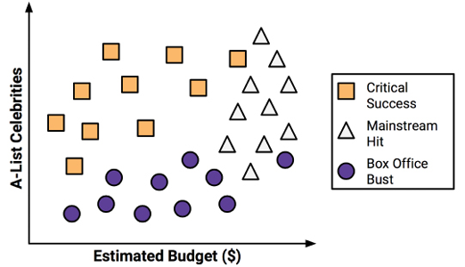

## Potential movie proposals example

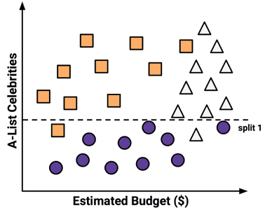

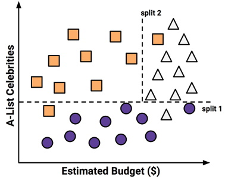

- partitioned the data into three groups
  - the top-left corner: critically acclaimed films
  - the top-right corner: box office hits
  - the below group: box office bust

## Potential movie proposals example

- you could continue to split the data on increasingly specific ranges of budget and celebrity count
- until each of the currently misclassified values is correctly classified in its own tiny partition
  - but it is likely to **overfit** a decision tree
- you choose to avoid the problem of overfitting by stopping the algorithm earlier

## Potential movie proposals example

- Use the model for predicting future success of movies

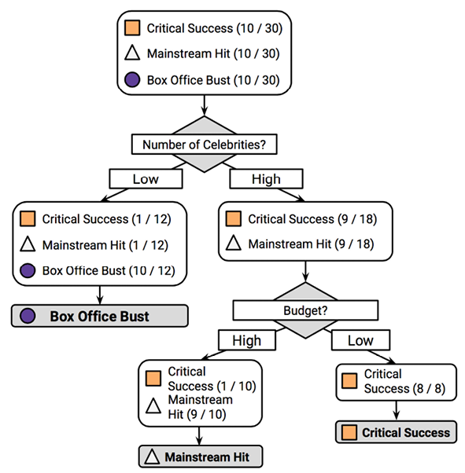

## Some details of the implementation of classification trees

- In the classification trees with binary splits algorithm, the **classification error rate** is a natural choice for criterion to minimize
- it means the fraction of the training observations in that region that `do not belong` to the most common class:

$$E = 1 − \max_k(\hat{p}_{mk})$$
$\quad$ $\hat{p}_{mk}$ represents the proportion of training observations in the $m$th region that are from the $k$th class

- for those who are more rigorous in definition
  - $\hat{p}_{mk}=\frac{1}{n_m} \sum_{x_i \in R_m} \indicator{y_i=k}$
  - $n_m$ is the total number of training observations in the $m$th region ($R_m$), i.e. $n_m=\sum^n_{i=1} \indicator{x_i \in R_m}$
- In practice, the classification error rate might not be a good criterion to build a tree
  - it is not sufficiently sensitive for tree-growing
- the `Gini index` and `Entropy` are more likely to be used

## The Gini index

The Gini index is defined by

$$G = \sum\limits^K_{k=1} \hat{p}_{mk}(1 − \hat{p}_{mk})$$

- The Gini index is a measure of total variance across the $K$ classes
- Gini takes on a small value if all of the $\hat{p}_{mk}$’s are close to 0 or 1
- the Gini index is referred to as a measure of node purity
  - a small value indicates that a node contains predominantly observations from a single class

## Entropy

- Entropy is given by

$$D = − \sum\limits^K_{k=1} \hat{p}_{mk} \log \hat{p}_{mk}$$

- Entropy is a measure of node impurity
  - a small value indicates that a node contains predominantly observations from a single class

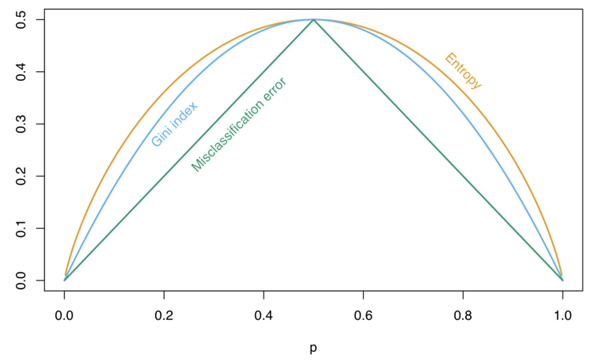

- the Entropy is closely related to the Gini index
- the Gini index and the Entropy are very similar numerically

## Regression Trees

- Decision trees can be applied to regression problems as well
- however, tree-based methods typically are **not competitive** with the best supervised learning approaches in terms of prediction accuracy though
- Base ball salary example

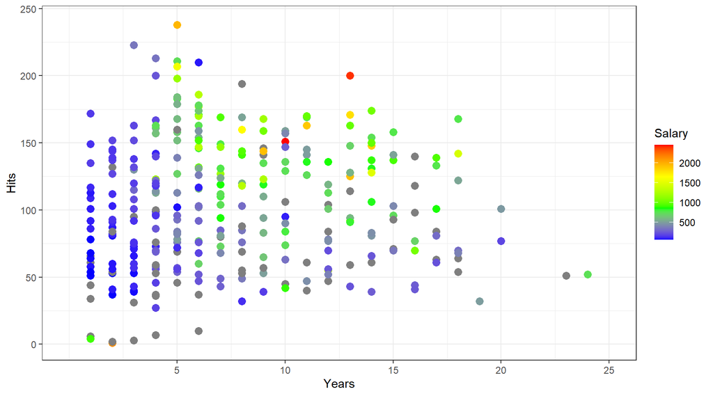

## Regression Trees - Baseball Salary Example

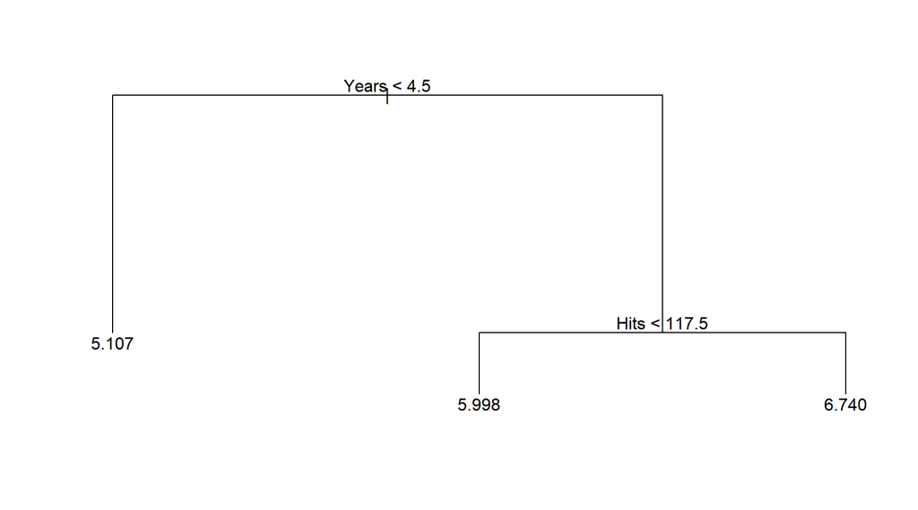

```r
library(tidyverse)

baseball<- read_csv("https://raw.githubusercontent.com/kwan-MSDA/MSDA7003/main/Hitters.csv")

baseball<- baseball %>%
  mutate(salary= log(Salary))


library(tree)
baseball_fit<- tree(salary ~ Years + Hits, data=baseball,
                    control=tree.control(nrow(baseball), minsize=100))
plot(baseball_fit)
text(baseball_fit, pretty=0)
```

## Regression Trees - Baseball Salary Example

let us look at the splits closer

```r
baseball_fit$frame$splits
```

```
     cutleft  cutright
[1,] "<4.5"   ">4.5"
[2,] ""       ""
[3,] "<117.5" ">117.5"
[4,] ""       ""
[5,] ""       ""
```

```r
splits<- baseball_fit$frame$splits %>%
  as.data.frame() %>%
  filter(cutleft !="") %>%
  mutate(val=readr::parse_number(cutleft)) %>%
  pull(val)

splits
```

```
[1]   4.5 117.5
```

## Regression Trees - Baseball Salary Example

- a regression tree for predicting the `log salary` of a baseball player
  - based on the number of years that he has played in the major leagues and the number of hits that he made in the previous year
- At a given internal node, the label (of the form $X_j < t_k$) indicates the left-hand branch emanating from that split
  - the right-hand branch corresponds to $X_j ≥ t_k$
- For instance, the split at the top of the tree results in two large branches
  - The left-hand branch corresponds to Years < 4.5
  - the right-hand branch corresponds to Years ≥ 4.5
- The tree has two internal nodes and three terminal nodes, or leaves
- The number in each leaf is the mean of the response for the observations that fall there

## Regression Trees - Baseball Salary Example

- The tree model splits the data into three groups
- let us visualize the splits

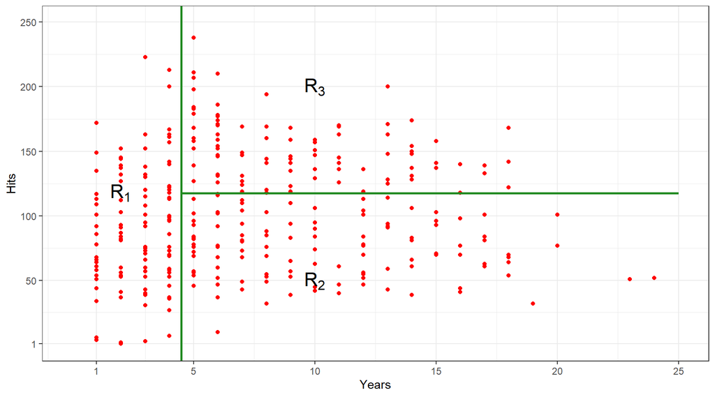

```r
baseball %>%
  ggplot(aes(x=Years, y=Hits)) +
  geom_point(color="red") +
  geom_vline(xintercept=splits[1], size=1, color="forestgreen") +
  geom_segment(aes(x=splits[1], xend=25, y=splits[2], yend=splits[2]),
               color="forestgreen", linewidth=1) +
  annotate("text", x=10, y=50, label="R[2]", size=6, parse=TRUE) +
  annotate("text", x=10, y=200, label="R[3]", size=6, parse=TRUE) +
  annotate("text", x=2, y=118, label="R[1]", size=6, parse=TRUE) +
  coord_cartesian(xlim=c(0, 25), ylim=c(0, 250)) +
  scale_x_continuous(breaks=c(1,seq(5, 25, by=5))) +
  scale_y_continuous(breaks=c(1, seq(50, 250, by=50))) +
  theme_bw()
```

- the tree stratifies the players into three regions of predictor space
  - $R_1 = \{X|Years < 4.5 \}$,
  - $R_2 = \{X|Years ≥ 4.5, Hits < 117.5 \}$
  - $R_3 = \{X|Years ≥ 4.5, Hits ≥ 117.5 \}$

## A bit details of the tree-building process

- divide the predictor space (the set of possible values for $X_1, X_2, . . . , X_p$ )
  - into $J$ `distinct` and `non-overlapping` regions, $R_1, R_2, . . . , R_J$
- For every observation that falls into the region $R_j$, the same prediction is made
  - the mean of the response values for the training observations in $R_j$
- in the process, the algorithm divides the predictor space into high-dimensional rectangles (box)
  - this offer simplicity and ease of interpretation of the resulting predictive model
- the goal is to find boxes $R_1, R_2, . . . , R_J$ that minimize the `mean squared error` of the response variable within each box

$$\sum_{j=1}^J \sum_{i \in R_j} (y_i - \hat{y}_{R_j})^2$$

$\quad$ where $\hat{y}_{R_j}$ is the `mean` response for the training observations in the $j^{th}$ box

## A bit details of the tree-building process

- In practice, the `recursive binary splitting` take a `top-down`, `greedy` approach (~ divide and conquer)
  - we do not go into details [the difference between the two approaches](https://www.geeksforgeeks.org/difference-between-greedy-algorithm-and-divide-and-conquer-algorithm/)
- **top-down**
  - it begins at the top of the tree and then successively splits the predictor space
  - each split is indicated via two new branches further down on the tree
- **greedy**
  - at each step of the tree-building process, the best split is made at that particular step
  - instead of looking ahead and picking a split that will lead to a better tree in some future step
- here are the steps
  - the algorithm searches over all predictors and all possible cut-points for each predictor
  - the predictor and cut-point that results in the `lowest mean squared error` are chosen
  - the data are split into two regions, and the process is repeated on each of the two regions
  - the tree is grown `recursively` until a stopping criterion is met

## More illustrations

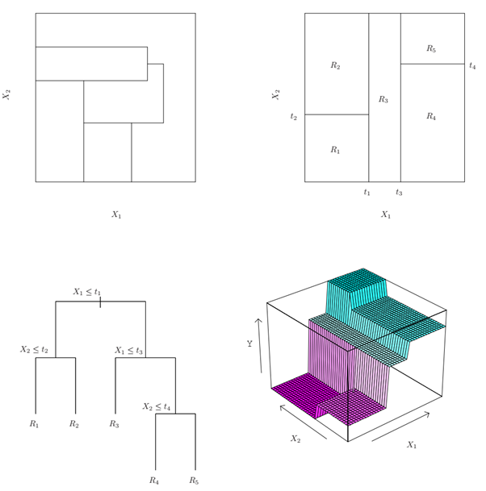

## Pruning a tree

- a tree that is too large might lead to `overfitting`
  - The splitting process may produce good predictions on the training set, but is likely to overfit the data, leading to poor test set performance
- One strategy is to grow the tree only so long as the decrease in the RSS due to each split exceeds some (high) threshold
  - this strategy will result in smaller trees
  - however, it is too short-sighted
    - a seemingly worthless split early on in the tree might be followed by a very good split — that is, a split that leads to a large reduction in RSS later on
- Another strategy is to grow a very large tree $T_0$, and then `prune` it back in order to obtain a `subtree`
  - in practice, this leads to a `lower test error rate`
  - the `cost complexity pruning` algorithm (also known as weakest link pruning) provides an automatic way to prune the tree

## Tree vs Linear Models

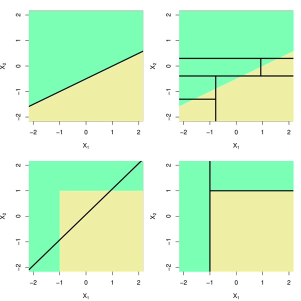

## Tree vs Linear Models

### Advantages of Trees

- Trees are very easy to explain to people
  - they are even easier to explain than linear regression
- Some people believe that decision trees more closely mirror human decision-making than do the regression and other classification approaches
  - e.g., “Middle-aged low-skilled self-employed male workers who reside in a small-flat unit in Sham Shui Po have the highest probability of defaulting on their credit card payments” could be a statement based on a tree model
- Trees can be displayed graphically, and are easily interpreted even by a non-expert
- Trees can easily handle qualitative predictors without the need to create dummy variables

## Tree vs Linear Models

### Disadvantages of Trees

- trees generally do not have the same level of predictive accuracy as some of the other regression and classification approaches
- they can be `prone to overfitting` the data
  - especially if the tree is allowed to grow without pruning, or the minimum number of samples per leaf set too low
- trees are locally optimal
  - a greedy algorithm is used to build the tree
  - it may not necessarily result in the best tree
- Lack of smoothness of the prediction surface in the regression setting
- trees can be very non-robust
  - a small change in the data can cause a large change in the final estimated tree
  - high variance
- As a remedy for the the variance problem, `bagging`, `random forests`, and `boosting` have been proposed

## References

James, G., D. Witten, T. Hastie, and R. Tibshirani. 2023. *An Introduction to Statistical Learning with Applications in r*. Second edition. Springer.

Lantz, Brett. 2023. *Machine Learning with r : Learn Techniques for Building and Improving Machine Learning Models, from Data Preparation to Model Tuning, Evaluation, and Working with Big Data*. Fourth edition. Expert Insight. Birmingham, UK: Packt Publishing Limited.

## Appendix - Cross-Entropy

- Cross-entropy is a measure from the field of information theory
  - it is used to quantify the difference between two probability distributions
  - it is commonly used in machine learning as a loss function
- The cross-entropy of the distribution $q$ relative to the distribution $p$ is defined as

$$H (p, q) = - ∑^M_{m=1} p_m \log (q_m),$$

$\quad$ where $(q_1, \cdots , q_M)$ are the predicted probabilities while $(p_1, \dots, p_M )$ are the true probabilities

- In information theory, the cross-entropy is the average message length to code data generated from $p$ under $q$ (in bits when the base for log is 2)
  - if the predicted probabilities match the true probabilities, the cross-entropy is equal to entropy, and the length is shortest